# ReneWind

Renewable energy sources play an increasingly important role in the global energy mix, as the effort to reduce the environmental impact of energy production increases.

Out of all the renewable energy alternatives, wind energy is one of the most developed technologies worldwide. The U.S Department of Energy has put together a guide to achieving operational efficiency using predictive maintenance practices.

Predictive maintenance uses sensor information and analysis methods to measure and predict degradation and future component capability. The idea behind predictive maintenance is that failure patterns are predictable and if component failure can be predicted accurately and the component is replaced before it fails, the costs of operation and maintenance will be much lower.

The sensors fitted across different machines involved in the process of energy generation collect data related to various environmental factors (temperature, humidity, wind speed, etc.) and additional features related to various parts of the wind turbine (gearbox, tower, blades, break, etc.).

## Objective

“ReneWind” is a company working on improving the machinery/processes involved in the production of wind energy using machine learning and has collected data of generator failure of wind turbines using sensors. They have shared a ciphered version of the data, as the data collected through sensors is confidential (the type of data collected varies with companies). Data has 40 predictors, 40000 observations in the training set and 10000 in the test set.

The objective is to build various classification models, tune them and find the best one that will help identify failures so that the generator could be repaired before failing/breaking and the overall maintenance cost of the generators can be brought down.

“1” in the target variables should be considered as “failure” and “0” will represent “No failure”.

The nature of predictions made by the classification model will translate as follows:

- True positives (TP) are failures correctly predicted by the model.
- False negatives (FN) are real failures in a wind turbine where there is no detection by model.
- False positives (FP) are detections in a wind turbine where there is no failure.

So, the maintenance cost associated with the model would be:

**Maintenance cost** = `TP*(Repair cost) + FN*(Replacement cost) + FP*(Inspection cost)` where,

- `Replacement cost = $40,000`
- `Repair cost = $15,000`
- `Inspection cost = $5,000`

Here the objective is to reduce the maintenance cost so, we want a metric that could reduce the maintenance cost.

- The minimum possible maintenance cost = `Actual failures*(Repair cost) = (TP + FN)*(Repair cost)`
- The maintenance cost associated with model = `TP*(Repair cost) + FN*(Replacement cost) + FP*(Inspection cost)`

So, we will try to maximize the ratio of minimum possible maintenance cost and the maintenance cost associated with the model.

The value of this ratio will lie between 0 and 1, the ratio will be 1 only when the maintenance cost associated with the model will be equal to the minimum possible maintenance cost.

## Data Description

- The data provided is a transformed version of original data which was collected using sensors.
- Train.csv - To be used for training and tuning of models.
- Test.csv - To be used only for testing the performance of the final best model.
- Both the datasets consist of 40 predictor variables and 1 target variable

## Importing libraries

```python
import warnings

warnings.filterwarnings("ignore")
# Libraries to help with reading and manipulating data
import pandas as pd
import numpy as np

# libaries to help with data visualization
import matplotlib.pyplot as plt
import seaborn as sns

# Libraries to tune model, get different metric scores, and split data
from sklearn import metrics
from sklearn.model_selection import train_test_split, StratifiedKFold, cross_val_score
from sklearn.preprocessing import StandardScaler
from sklearn.model_selection import GridSearchCV, RandomizedSearchCV

from sklearn.metrics import (
    f1_score,
    accuracy_score,
    recall_score,
    precision_score,
    confusion_matrix,
    roc_auc_score,
    plot_confusion_matrix,
    precision_recall_curve,
    roc_curve,
    make_scorer
)

from sklearn.impute import KNNImputer
from sklearn.pipeline import Pipeline, make_pipeline

#libraries to help with model building
from sklearn.linear_model import LogisticRegression
from sklearn.tree import DecisionTreeClassifier
from sklearn.ensemble import (
    AdaBoostClassifier,
    GradientBoostingClassifier,
    RandomForestClassifier,
    BaggingClassifier)
from xgboost import XGBClassifier
from sklearn.impute import SimpleImputer

# to suppress scientific notations
pd.set_option('display.float_format', lambda x: '%.3f' % x)
```

## Loading Data

```python
data = pd.read_csv('Train.csv')
```

## EDA and insights

```python
data.head()
```

|  | V1 | V2 | V3 | V4 | V5 | V6 | V7 | V8 | V9 | V10 | ... | V32 | V33 | V34 | V35 | V36 | V37 | V38 | V39 | V40 | Target |
| --- | --- | --- | --- | --- | --- | --- | --- | --- | --- | --- | --- | --- | --- | --- | --- | --- | --- | --- | --- | --- | --- |
| 0 | -4.465 | -4.679 | 3.102 | 0.506 | -0.221 | -2.033 | -2.911 | 0.051 | -1.522 | 3.762 | ... | 3.060 | -1.690 | 2.846 | 2.235 | 6.667 | 0.444 | -2.369 | 2.951 | -3.480 | 0 |
| 1 | -2.910 | -2.569 | 4.109 | 1.317 | -1.621 | -3.827 | -1.617 | 0.669 | 0.387 | 0.854 | ... | -3.783 | -6.823 | 4.909 | 0.482 | 5.338 | 2.381 | -3.128 | 3.527 | -3.020 | 0 |
| 2 | 4.284 | 5.105 | 6.092 | 2.640 | -1.041 | 1.308 | -1.876 | -9.582 | 3.470 | 0.763 | ... | -3.098 | 2.690 | -1.643 | 7.566 | -3.198 | -3.496 | 8.105 | 0.562 | -4.227 | 0 |
| 3 | 3.366 | 3.653 | 0.910 | -1.368 | 0.332 | 2.359 | 0.733 | -4.332 | 0.566 | -0.101 | ... | -1.795 | 3.033 | -2.468 | 1.895 | -2.298 | -1.731 | 5.909 | -0.386 | 0.616 | 0 |
| 4 | -3.832 | -5.824 | 0.634 | -2.419 | -1.774 | 1.017 | -2.099 | -3.173 | -2.082 | 5.393 | ... | -0.257 | 0.804 | 4.086 | 2.292 | 5.361 | 0.352 | 2.940 | 3.839 | -4.309 | 0 |

5 rows × 41 columns

```python
data.shape
```

```
(40000, 41)
```

- The dataset has 40000 rows and 41 columns

```python
data.info()
```

```
<class 'pandas.core.frame.DataFrame'>
RangeIndex: 40000 entries, 0 to 39999
Data columns (total 41 columns):
 #   Column  Non-Null Count  Dtype
---  ------  --------------  -----
 0   V1      39954 non-null  float64
 1   V2      39961 non-null  float64
 2   V3      40000 non-null  float64
 3   V4      40000 non-null  float64
 4   V5      40000 non-null  float64
 5   V6      40000 non-null  float64
 6   V7      40000 non-null  float64
 7   V8      40000 non-null  float64
 8   V9      40000 non-null  float64
 9   V10     40000 non-null  float64
```

[output cut: 33 more lines]

- all columns are float exsept the Target that is integer
- also we have some missing value in two columns( v1 & v2)

```python
data.duplicated().sum()#no duplicate value
```

```
0
```

## Univariate analysis

```python
# While doing uni-variate analysis of numerical variables we want to study their central tendency
# and dispersion.
# Let us write a function that will help us create a boxplot and histogram for any input numerical
# variable.
# This function takes the numerical column as the input and returns the boxplots
# and histograms for the variable.
# Let us see if this helps us write faster and cleaner code.
def histogram_boxplot(feature, figsize=(15,10), bins = None):
    """ Boxplot and histogram combined
    feature: 1-d feature array
    figsize: size of fig (default (9,8))
    bins: number of bins (default None / auto)
    """
    f2, (ax_box2, ax_hist2) = plt.subplots(nrows = 2, # Number of rows of the subplot grid= 2
                                           sharex = True, # x-axis will be shared among all subplots
                                           gridspec_kw = {"height_ratios": (.25, .75)},
                                           figsize = figsize
                                           ) # creating the 2 subplots
    sns.boxplot(feature, ax=ax_box2, showmeans=True, color='violet') # boxplot will be created and a star will indicate the mean value of the column
    sns.distplot(feature, kde=F, ax=ax_hist2, bins=bins,color = 'orange') if bins else sns.distplot(feature, kde=False, ax=ax_hist2,color='tab:cyan') # For histogram
    ax_hist2.axvline(np.mean(feature), color='purple', linestyle='--') # Add mean to the histogram
    ax_hist2.axvline(np.median(feature), color='black', linestyle='-') # Add median to the histogram
```

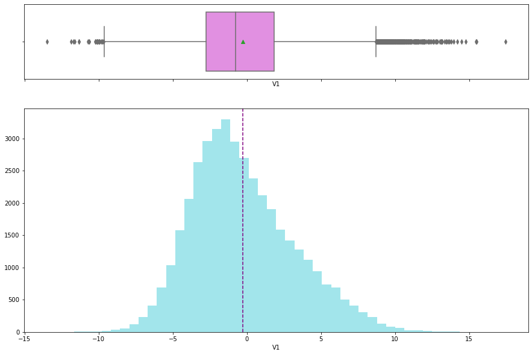

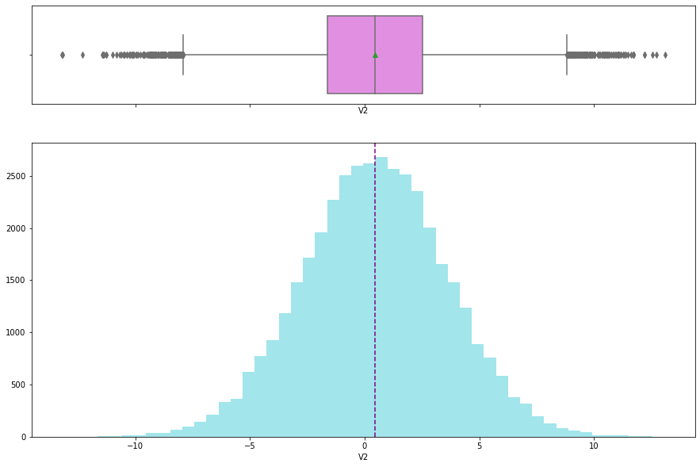

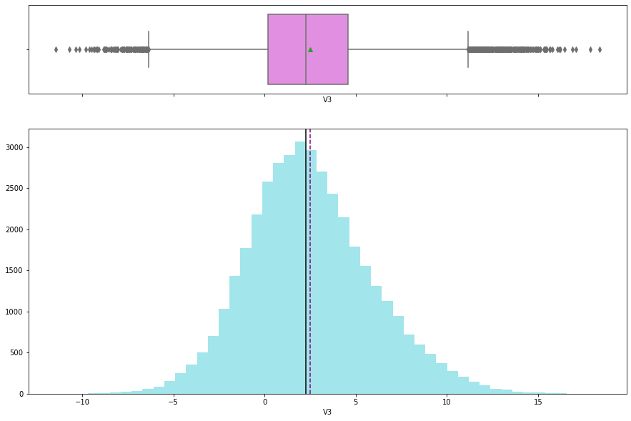

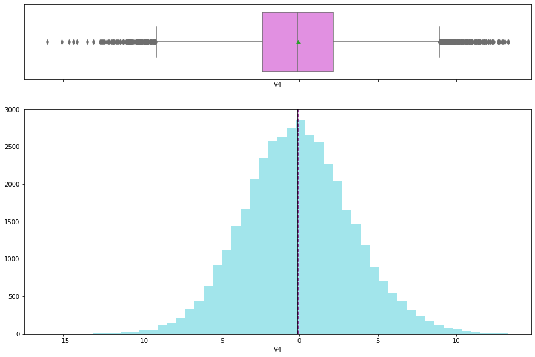

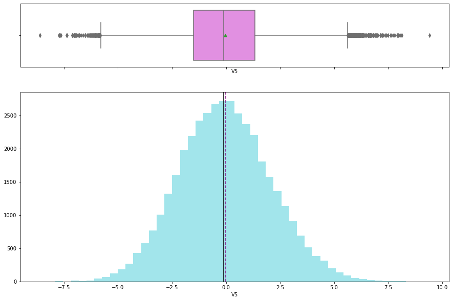

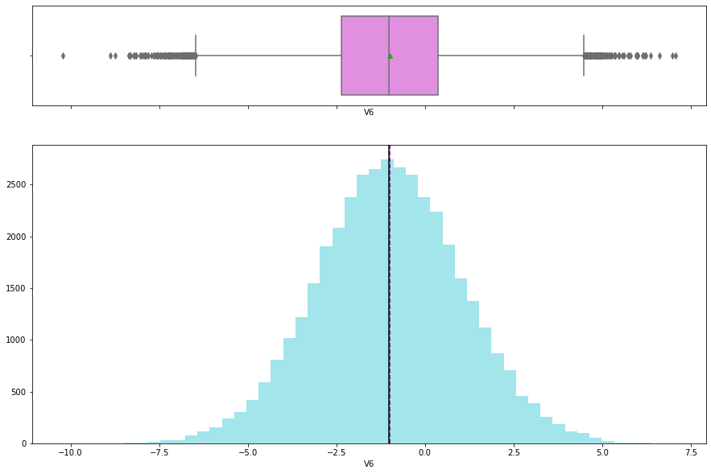

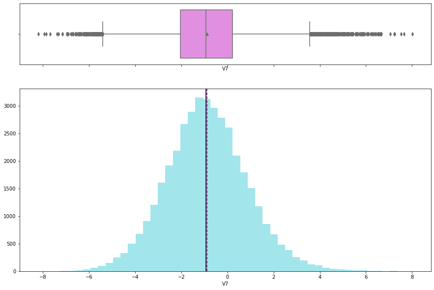

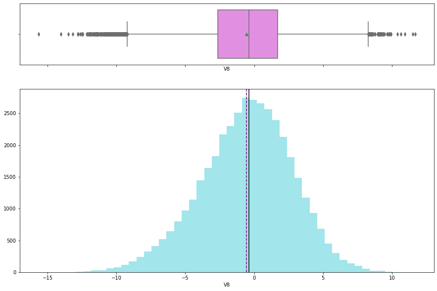

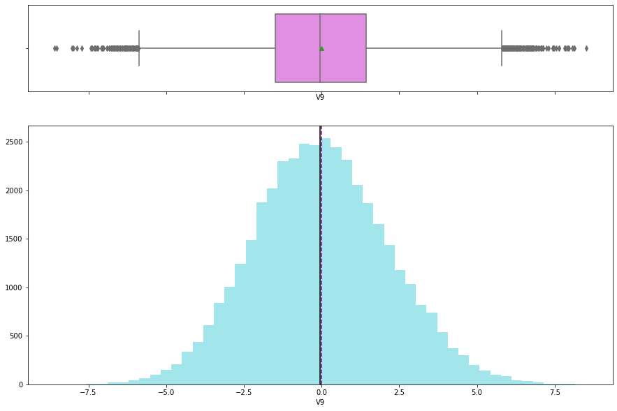

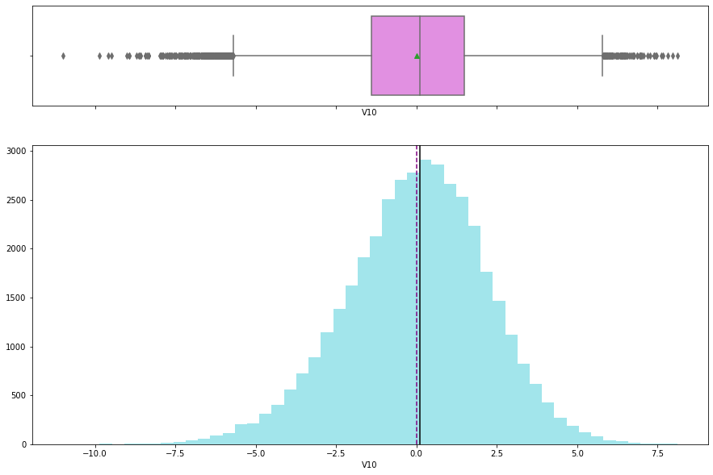

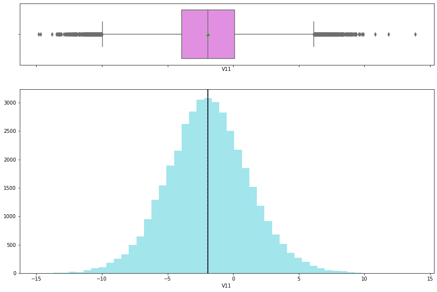

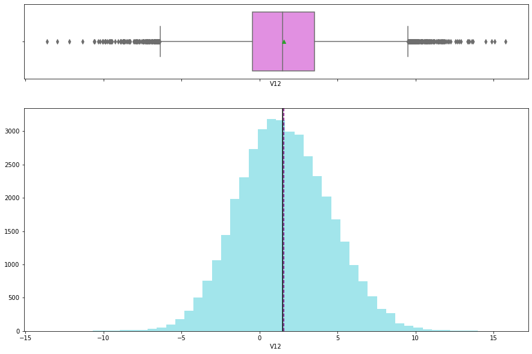

[28 more figures not shown]

```python
for i in range(1,41):
    histogram_boxplot(data['V'+str(i)])
```

## Data Pre-processing

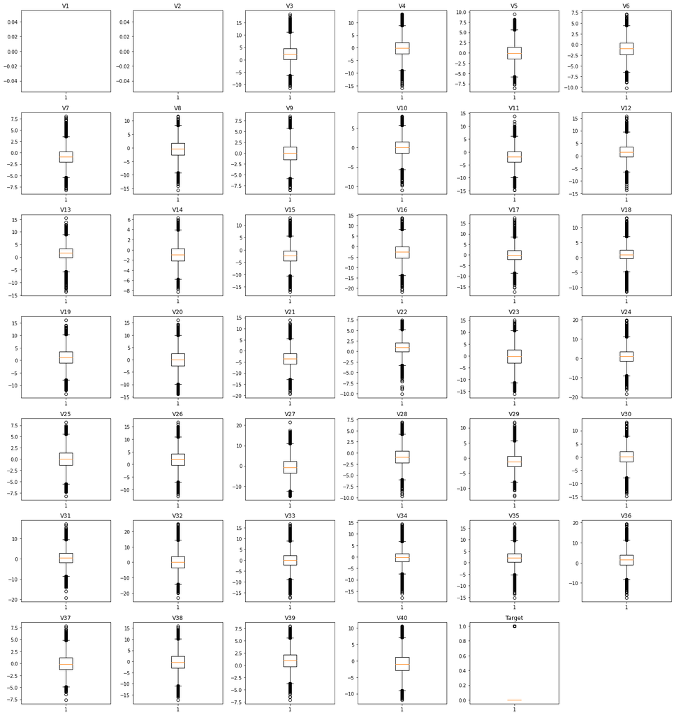

```python
# let's plot the boxplots of all columns to check for outliers
plt.figure(figsize=(20, 30))

for i, variable in enumerate(data):
    plt.subplot(10, 6, i + 1)
    plt.boxplot(data[variable], whis=1.5)
    plt.tight_layout()
    plt.title(variable)

plt.show()
```

```python
def treat_outliers(data, col):
    """
    treats outliers in a variable
    col: str, name of the numerical variable
    df: dataframe
    col: name of the column
    """
    Q1 = data[col].quantile(0.25)  # 25th quantile
    Q3 = data[col].quantile(0.75)  # 75th quantile
    IQR = Q3 - Q1
    Lower_Whisker = Q1 - 1.5 * IQR
    Upper_Whisker = Q3 + 1.5 * IQR

    # all the values smaller than Lower_Whisker will be assigned the value of Lower_Whisker
    # all the values greater than Upper_Whisker will be assigned the value of Upper_Whisker
    data[col] = np.clip(data[col], Lower_Whisker, Upper_Whisker)

    return data


def treat_outliers_all(data, col_list):
    """
    treat outlier in all numerical variables
    col_list: list of numerical variables
    df: data frame
    """
    for c in col_list:
         if (c!='V1')& (c!='V2')& (c!='Target'):
            data = treat_outliers(data, c)

    return data
```

```python
data = treat_outliers_all(data, data)
```

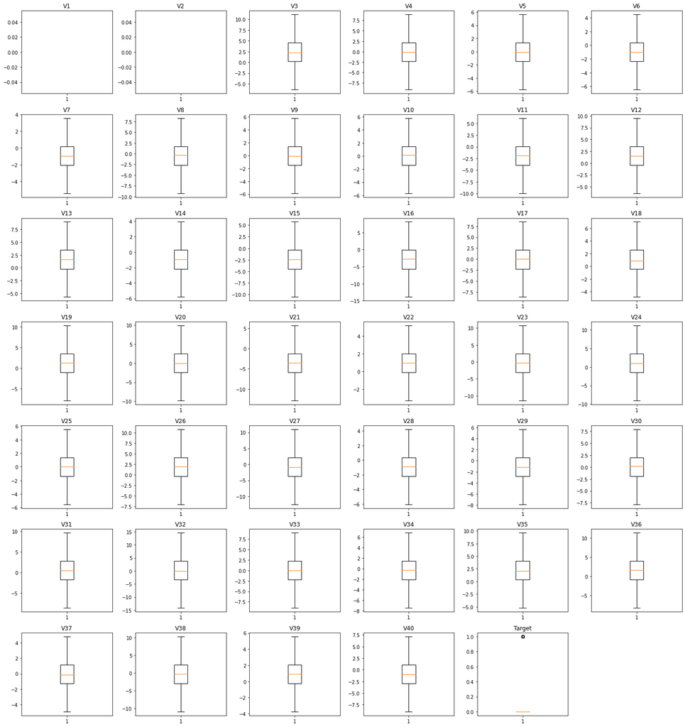

```python
# let's look at the boxplots to see if the outliers have been treated or not
plt.figure(figsize=(20, 30))

for i, variable in enumerate(data):
    plt.subplot(10, 6, i + 1)
    plt.boxplot(data[variable], whis=1.5)
    plt.tight_layout()
    plt.title(variable)

plt.show()
```

### Missing-Value Treatment

- We will use median to impute missing values.
- insted of mean I choose median because the median of a variable is the value that lies in the middle of the data when arranged in ascending order and does not depend on the extreme values of the data.

```python
data.isnull().sum()# v1 has 46 and v2 has 39 missing value
```

```
V1        46
V2        39
V3         0
V4         0
V5         0
V6         0
V7         0
V8         0
V9         0
V10        0
V11        0
V12        0
V13        0
V14        0
V15        0
V16        0
V17        0
V18        0
V19        0
V20        0
V21        0
V22        0
V23        0
V24        0
V25        0
V26        0
V27        0
V28        0
V29        0
V30        0
V31        0
V32        0
V33        0
V34        0
V35        0
V36        0
V37        0
V38        0
V39        0
V40        0
Target     0
dtype: int64
```

```python
#since we have two separate data frames for this project [train data and test data], we do not need to split the data to train and test
#but it is good to split data to see which model performance is better
X = data.drop(['Target'],axis=1)
Y = data['Target']

# Splitting data in train and test sets
X_train, X_val, y_train, y_val = train_test_split(
    X, Y, test_size=0.30, random_state=1)

# fill missing values with median column values
imputer = SimpleImputer(strategy='median', fill_value = 'numerical')
X_train=pd.DataFrame(imputer.fit_transform(X_train),columns=X_train.columns)
X_val=pd.DataFrame(imputer.transform(X_val),columns=X_val.columns)
```

```python
print(X_train.isna().sum())#Checking that no column has missing values
```

```
V1     0
V2     0
V3     0
V4     0
V5     0
V6     0
V7     0
V8     0
V9     0
V10    0
V11    0
V12    0
V13    0
V14    0
V15    0
V16    0
V17    0
V18    0
V19    0
V20    0
V21    0
V22    0
V23    0
V24    0
V25    0
V26    0
V27    0
V28    0
V29    0
V30    0
V31    0
V32    0
V33    0
V34    0
V35    0
V36    0
V37    0
V38    0
V39    0
V40    0
dtype: int64
```

## Model evaluation criterion

### 3 types of cost are associated with the provided problem

1. Replacement cost - False Negatives - Predicting no failure, while there will be a failure
2. Inspection cost - False Positives - Predicting failure, while there is no failure
3. Repair cost - True Positives - Predicting failure correctly

### How to reduce the overall cost?

- We need to create a customized metric, that can help to bring down the overall cost.
- The cost associated with any model = TP *15000 + FP* 5000 + FN * 40000
- And the minimum possible cost will be when, the model will be able to identify all failures, in that case, the cost will be (TP + FN) * 15000
- So, we will try to maximize `Minimum cost/Cost associated with model`

**Let's create two functions to calculate different metrics and confusion matrix, so that we don't have to use the same code repeatedly for each model.**

```python
# defining a function to compute different metrics to check performance of a classification model built using sklearn
def model_performance_classification_sklearn(model, predictors, target):
    """
    Function to compute different metrics to check classification model performance

    model: classifier
    predictors: independent variables
    target: dependent variable
    """

    TP = confusion_matrix(target, model.predict(predictors))[1, 1]
    FP = confusion_matrix(target, model.predict(predictors))[0, 1]
    FN = confusion_matrix(target, model.predict(predictors))[1, 0]
    Cost = TP * 15 + FP * 5 + FN * 40  # maintenance cost by using model
    Min_Cost = (TP + FN) * 15  # minimum possible maintenance cost = number of actual positives
    Percent = Min_Cost / Cost  # ratio of minimum possible maintenance cost and maintenance cost by model

    # predicting using the independent variables
    pred = model.predict(predictors)

    acc = accuracy_score(target, pred)  # to compute Accuracy
    recall = recall_score(target, pred)  # to compute Recall
    precision = precision_score(target, pred)  # to compute Precision
    f1 = f1_score(target, pred)  # to compute F1-score

    # creating a dataframe of metrics
    df_perf = pd.DataFrame(
        {
            "Accuracy": acc,
            "Recall": recall,
            "Precision": precision,
            "F1": f1,
            "Minimum_Vs_Model_cost": Percent,
        },
        index=[0],
    )

    return df_perf
```

```python
def confusion_matrix_sklearn(model, predictors, target):
    """
    To plot the confusion_matrix with percentages

    model: classifier
    predictors: independent variables
    target: dependent variable
    """
    y_pred = model.predict(predictors)
    cm = confusion_matrix(target, y_pred)
    labels = np.asarray(
        [
            ["{0:0.0f}".format(item) + "\n{0:.2%}".format(item / cm.flatten().sum())]
            for item in cm.flatten()
        ]
    ).reshape(2, 2)

    plt.figure(figsize=(6, 4))
    sns.heatmap(cm, annot=labels, fmt="")
    plt.ylabel("True label")
    plt.xlabel("Predicted label")
```

## **Defining scorer to be used for hyperparameter tuning**

- Every prediction of a classification model will be either a TP, FP, FN or TN.
- Till now at most of the places we wanted to reduce False negatives and hence we tried to maximize "Recall".
- To maximize Recall, we used Recall as a **scorer** in hyperparameter tuning.
- Here, we not only want to minimize false negatives but also false positives and we are also given the costs associated with each type of prediction.
- So, overall we want to reduce the maintenance cost which is: `TP*(Repair cost) + FN*(Replacement cost) + FP*(Inspection cost)`
- In simple language, we can say that we are assigning different weightage to the different types of predictions.
- Do we have any such metric which can help us minimize the maintenance cost? i.e., help us reduce FP and FN as per the weightage - We don't have any such inbuilt metric.
- In sklearn, we can define **custom scorers** also as per our need.
- For this classification problem, we need to reduce the maintenance cost, which can be reiterated as:
  - Minimize (maintenance cost)
  - Maximize (1/maintenance cost)
  - Maximize (minimum possible maintenance cost/maintenance cost)
- Eventually, all 3 metrics will do the same work in the backend and the only difference will be in the scale of the values of the metric.
- The metric provided in the next cell is to `maximize(minimum possible maintenance cost/maintenance cost)`
- You can modify the metric as per convenience and use it further to tune the models.

```python
# defining metric to be used for optimization and with cross-validation
def Minimum_Vs_Model_cost(y_train, y_pred):
    """
    We want the model to optimize the maintenance cost and reduce it to the lowest possible value.
    The lowest possible maintenance cost will be achieved when each sample is predicted correctly.

    In such a scenario, the maintenance cost will be the total number of failures times the maintenance cost of replacing one generator,
    which is given by (TP + FN) * 40 (i.e., the actual positives*40).
    For any other scenario,
    the maintenance cost associated with the model will be given by (TP * 15 + FP * 5 + FN * 40).

    We will use the ratio of these two maintenance costs as the cost function for our model.
    The greater the ratio, the lower the associated maintenance cost and the better the model.
    """
    TP = confusion_matrix(y_train, y_pred)[1, 1]
    FP = confusion_matrix(y_train, y_pred)[0, 1]
    FN = confusion_matrix(y_train, y_pred)[1, 0]
    return ((TP + FN) * 15) / (TP * 15 + FP * 5 + FN * 40)


# A value of .80 here, will represent that the minimum maintenance cost is 80% of the maintenance cost associated with the model.
# Since minimum maintenance cost is constant for any data, when minimum cost will become 100% of maintenance cost associated with the model
# Model will have give the least possible maintenance cost.


# Type of scoring used to compare parameter combinations
scorer = metrics.make_scorer(Minimum_Vs_Model_cost, greater_is_better=True)

# Higher the values, the lower the maintenance cost
```

## Model Building with Original data

### LogisticRegression

```python
lr = LogisticRegression(random_state=1)
lr.fit(X_train,y_train)
```

```
LogisticRegression(random_state=1)
```

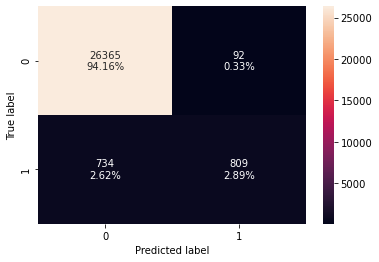

```python
confusion_matrix_sklearn(lr, X_train, y_train)
```

True positives (TP) that are failures correctly predicted by the model is 2.89% False negatives (FN) that are real failures in the generator of wind turbine where there is no detection by the model is 2.62% False positives (FP) that are failure detections in the generator of the wind turbine where actually there is no failure is 0.33% True negative (TN) that are real no failears correctly predicted by the model is 94.16%

```python
log_reg_model_train_perf =model_performance_classification_sklearn(
    lr, X_train, y_train
)

print("Training performance:")
log_reg_model_train_perf
```

```
Training performance:
```

|  | Accuracy | Recall | Precision | F1 | Minimum_Vs_Model_cost |
| --- | --- | --- | --- | --- | --- |
| 0 | 0.971 | 0.524 | 0.898 | 0.662 | 0.552 |

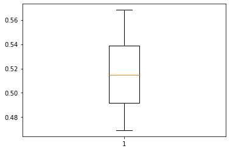

```python
scoring='recall'
kfold=StratifiedKFold(n_splits=5,shuffle=True,random_state=1)     #Setting number of splits equal to 5
cv_result_bfr=cross_val_score(estimator=lr, X=X_train, y=y_train, scoring=scoring, cv=kfold)
#Plotting boxplots for CV scores of model defined above
plt.boxplot(cv_result_bfr)
plt.show()
```

Performance on training set varies between 0.47 to 0.57 recall.

```python
log_reg_model_val_perf=model_performance_classification_sklearn(
    lr, X_val, y_val
)

print("Training performance:")
log_reg_model_val_perf
```

```
Training performance:
```

|  | Accuracy | Recall | Precision | F1 | Minimum_Vs_Model_cost |
| --- | --- | --- | --- | --- | --- |
| 0 | 0.973 | 0.545 | 0.909 | 0.682 | 0.563 |

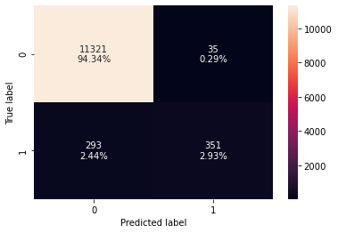

```python
confusion_matrix_sklearn(lr, X_val, y_val)
```

Performance on the training and validation set are not bad. Minimum_Vs_Model_cost is not high enough

### Decision Tree model

```python
model = DecisionTreeClassifier(random_state=1)
```

```python
model.fit(X_train, y_train)
```

```
DecisionTreeClassifier(random_state=1)
```

```python
confusion_matrix_sklearn(model, X_train, y_train)
```

[output not shown]

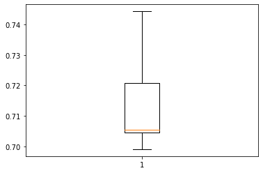

```python
scoring='recall'
kfold=StratifiedKFold(n_splits=5,shuffle=True,random_state=1)     #Setting number of splits equal to 5
cv_result_bfr=cross_val_score(estimator=model, X=X_train, y=y_train, scoring=scoring, cv=kfold)
#Plotting boxplots for CV scores of model defined above
plt.boxplot(cv_result_bfr)
plt.show()
```

Performance on training set varies between 0.70 to 0.75 recall, which is an improvement from the previous model

```python
DecisionTree_train_perf =model_performance_classification_sklearn(
    model, X_train, y_train
)

print("Training performance:")
DecisionTree_train_perf
```

```
Training performance:
```

|  | Accuracy | Recall | Precision | F1 | Minimum_Vs_Model_cost |
| --- | --- | --- | --- | --- | --- |
| 0 | 1.000 | 1.000 | 1.000 | 1.000 | 1.000 |

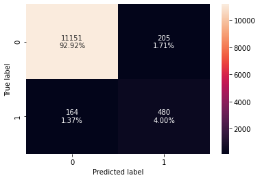

```python
# creating confusion matrix
confusion_matrix_sklearn(model, X_val, y_val)
```

```python
DecisionTree_val_perf =model_performance_classification_sklearn(
    model, X_val, y_val
)

print("Training performance:")
DecisionTree_val_perf
```

```
Training performance:
```

|  | Accuracy | Recall | Precision | F1 | Minimum_Vs_Model_cost |
| --- | --- | --- | --- | --- | --- |
| 0 | 0.969 | 0.745 | 0.701 | 0.722 | 0.653 |

model performance is very good on train set but the model is not able to replicate the same for the validation set.

### Random forest

```python
rf_estimator = RandomForestClassifier(random_state=1)
```

```python
rf_estimator.fit(X_train, y_train)
```

```
RandomForestClassifier(random_state=1)
```

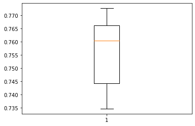

```python
scoring='recall'
kfold=StratifiedKFold(n_splits=5,shuffle=True,random_state=1)     #Setting number of splits equal to 5
cv_result_bfr=cross_val_score(estimator=rf_estimator, X=X_train, y=y_train, scoring=scoring, cv=kfold)
#Plotting boxplots for CV scores of model defined above
plt.boxplot(cv_result_bfr)
plt.show()
```

Performance on training set varies between 0.73 to 0.77 recall, which is a small improvement from the previous model

```python
confusion_matrix_sklearn(rf_estimator, X_train, y_train)
```

[output not shown]

```python
random_forest_train =model_performance_classification_sklearn(
    rf_estimator, X_train, y_train
)

print("Training performance:")
random_forest_train
```

```
Training performance:
```

|  | Accuracy | Recall | Precision | F1 | Minimum_Vs_Model_cost |
| --- | --- | --- | --- | --- | --- |
| 0 | 1.000 | 1.000 | 1.000 | 1.000 | 1.000 |

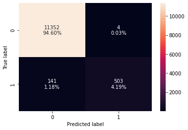

```python
confusion_matrix_sklearn(rf_estimator, X_val, y_val)
```

```python
random_forest_val=model_performance_classification_sklearn(
    rf_estimator, X_val, y_val
)

print("Training performance:")
random_forest_val
```

```
Training performance:
```

|  | Accuracy | Recall | Precision | F1 | Minimum_Vs_Model_cost |
| --- | --- | --- | --- | --- | --- |
| 0 | 0.988 | 0.781 | 0.992 | 0.874 | 0.732 |

model performance is good on train and validation sets but Recall and F1 scores dropped

### Bagging classifier model

```python
bagging_classifier = BaggingClassifier(random_state=1)
bagging_classifier.fit(X_train,y_train)
```

```
BaggingClassifier(random_state=1)
```

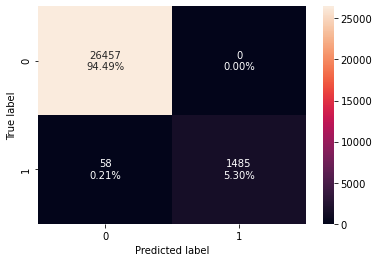

```python
confusion_matrix_sklearn(bagging_classifier, X_train, y_train)
```

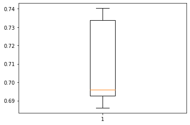

```python
scoring='recall'
kfold=StratifiedKFold(n_splits=5,shuffle=True,random_state=1)     #Setting number of splits equal to 5
cv_result_bfr=cross_val_score(estimator=bagging_classifier, X=X_train, y=y_train, scoring=scoring, cv=kfold)
#Plotting boxplots for CV scores of model defined above
plt.boxplot(cv_result_bfr)
plt.show()
```

Performance on training set varies between 0.68 to 0.74 recall, which is not improvement from the previous model

```python
bagging_score =model_performance_classification_sklearn(
    bagging_classifier, X_train, y_train
)

print("Training performance:")
bagging_score
```

```
Training performance:
```

|  | Accuracy | Recall | Precision | F1 | Minimum_Vs_Model_cost |
| --- | --- | --- | --- | --- | --- |
| 0 | 0.998 | 0.962 | 1.000 | 0.981 | 0.941 |

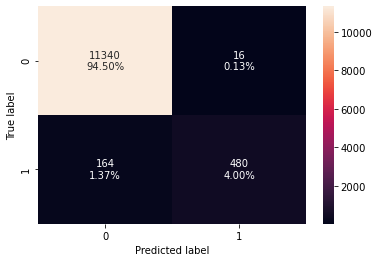

```python
confusion_matrix_sklearn(bagging_classifier, X_val, y_val)
```

```python
bagging_score_val =model_performance_classification_sklearn(
    bagging_classifier, X_val, y_val
)

print("Training performance:")
bagging_score_val
```

```
Training performance:
```

|  | Accuracy | Recall | Precision | F1 | Minimum_Vs_Model_cost |
| --- | --- | --- | --- | --- | --- |
| 0 | 0.985 | 0.745 | 0.968 | 0.842 | 0.698 |

model performance on the train and validation is good but recall score dropped

### Boosting Classifier

```python
ab_classifier = AdaBoostClassifier(random_state=1)
ab_classifier.fit(X_train,y_train)
```

```
AdaBoostClassifier(random_state=1)
```

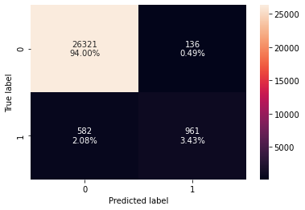

```python
confusion_matrix_sklearn(ab_classifier, X_train, y_train)
```

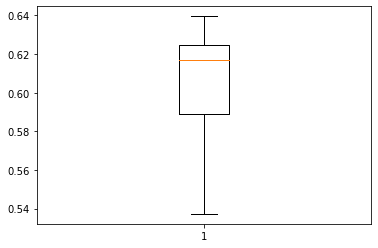

```python
scoring='recall'
kfold=StratifiedKFold(n_splits=5,shuffle=True,random_state=1)     #Setting number of splits equal to 5
cv_result_bfr=cross_val_score(estimator=ab_classifier, X=X_train, y=y_train, scoring=scoring, cv=kfold)
#Plotting boxplots for CV scores of model defined above
plt.boxplot(cv_result_bfr)
plt.show()
```

Performance on training set varies between 0.54 to 0.64 recall.there is no improvment

```python
Adaboost_score =model_performance_classification_sklearn(
    ab_classifier, X_train, y_train
)

print("Training performance:")
Adaboost_score
```

```
Training performance:
```

|  | Accuracy | Recall | Precision | F1 | Minimum_Vs_Model_cost |
| --- | --- | --- | --- | --- | --- |
| 0 | 0.974 | 0.623 | 0.876 | 0.728 | 0.603 |

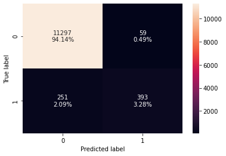

```python
confusion_matrix_sklearn(ab_classifier, X_val, y_val)
```

```python
Adaboost_score_val =model_performance_classification_sklearn(
    ab_classifier, X_val, y_val
)

print("Training performance:")
Adaboost_score_val
```

```
Training performance:
```

|  | Accuracy | Recall | Precision | F1 | Minimum_Vs_Model_cost |
| --- | --- | --- | --- | --- | --- |
| 0 | 0.974 | 0.610 | 0.869 | 0.717 | 0.595 |

The model is giving a generalized performance.

### Gradient Boosting Classifier

```python
gb_classifier = GradientBoostingClassifier(random_state=1)
gb_classifier.fit(X_train,y_train)
```

```
GradientBoostingClassifier(random_state=1)
```

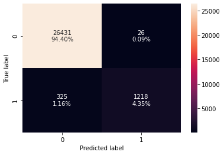

```python
#Creating confusion matrix
confusion_matrix_sklearn(gb_classifier, X_train, y_train)
```

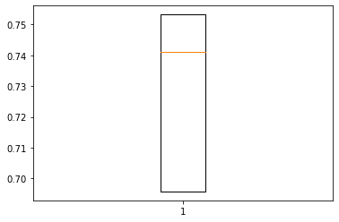

```python
scoring='recall'
kfold=StratifiedKFold(n_splits=5,shuffle=True,random_state=1)     #Setting number of splits equal to 5
cv_result_bfr=cross_val_score(estimator=gb_classifier, X=X_train, y=y_train, scoring=scoring, cv=kfold)
#Plotting boxplots for CV scores of model defined above
plt.boxplot(cv_result_bfr)
plt.show()
```

Performance on training set varies between 0.69 to 0.76 recall. which is an improvement from the previous model

```python
gb_classifier_score =model_performance_classification_sklearn(
    gb_classifier, X_train, y_train
)

print("Training performance:")
gb_classifier_score
```

```
Training performance:
```

|  | Accuracy | Recall | Precision | F1 | Minimum_Vs_Model_cost |
| --- | --- | --- | --- | --- | --- |
| 0 | 0.987 | 0.789 | 0.979 | 0.874 | 0.737 |

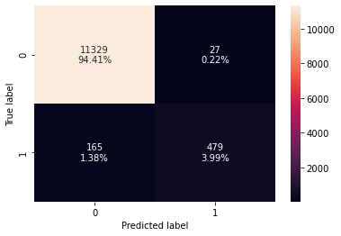

```python
confusion_matrix_sklearn(gb_classifier, X_val, y_val)
```

```python
gb_classifier_val =model_performance_classification_sklearn(
    gb_classifier, X_val, y_val
)

print("Training performance:")
gb_classifier_val
```

```
Training performance:
```

|  | Accuracy | Recall | Precision | F1 | Minimum_Vs_Model_cost |
| --- | --- | --- | --- | --- | --- |
| 0 | 0.984 | 0.744 | 0.947 | 0.833 | 0.694 |

The model is giving a generalized performance. Minimum_Vs_Model_cost score has been imporved

### XGBoost Classifier

```python
xgb_classifier = XGBClassifier(random_state=1,eval_metric='logloss')
xgb_classifier.fit(X_train,y_train)
```

```
XGBClassifier(base_score=0.5, booster='gbtree', colsample_bylevel=1,
              colsample_bynode=1, colsample_bytree=1, eval_metric='logloss',
              gamma=0, gpu_id=-1, importance_type='gain',
              interaction_constraints='', learning_rate=0.300000012,
              max_delta_step=0, max_depth=6, min_child_weight=1, missing=nan,
              monotone_constraints='()', n_estimators=100, n_jobs=8,
              num_parallel_tree=1, random_state=1, reg_alpha=0, reg_lambda=1,
              scale_pos_weight=1, subsample=1, tree_method='exact',
              validate_parameters=1, verbosity=None)
```

```python
#Creating confusion matrix
confusion_matrix_sklearn(xgb_classifier, X_train, y_train)
```

[output not shown]

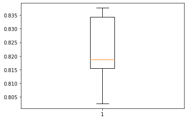

```python
scoring='recall'
kfold=StratifiedKFold(n_splits=5,shuffle=True,random_state=1)     #Setting number of splits equal to 5
cv_result_bfr=cross_val_score(estimator=xgb_classifier, X=X_train, y=y_train, scoring=scoring, cv=kfold)
#Plotting boxplots for CV scores of model defined above
plt.boxplot(cv_result_bfr)
plt.show()
```

Performance on training set varies between 0.80 to 0.83 recall. which is an improvement from the previous model

```python
xgb_classifier_score =model_performance_classification_sklearn(
    xgb_classifier, X_train, y_train
)

print("Training performance:")
xgb_classifier_score
```

```
Training performance:
```

|  | Accuracy | Recall | Precision | F1 | Minimum_Vs_Model_cost |
| --- | --- | --- | --- | --- | --- |
| 0 | 1.000 | 1.000 | 1.000 | 1.000 | 1.000 |

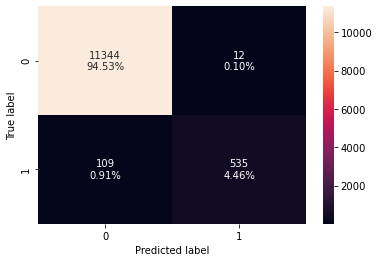

```python
confusion_matrix_sklearn(xgb_classifier, X_val, y_val)
```

```python
xgb_classifier_score_val =model_performance_classification_sklearn(
    xgb_classifier, X_val, y_val
)

print("Training performance:")
xgb_classifier_score_val
```

```
Training performance:
```

|  | Accuracy | Recall | Precision | F1 | Minimum_Vs_Model_cost |
| --- | --- | --- | --- | --- | --- |
| 0 | 0.990 | 0.831 | 0.978 | 0.898 | 0.776 |